# FIT5149 Assignment1

## Comparing the performances in LR

[output not shown]

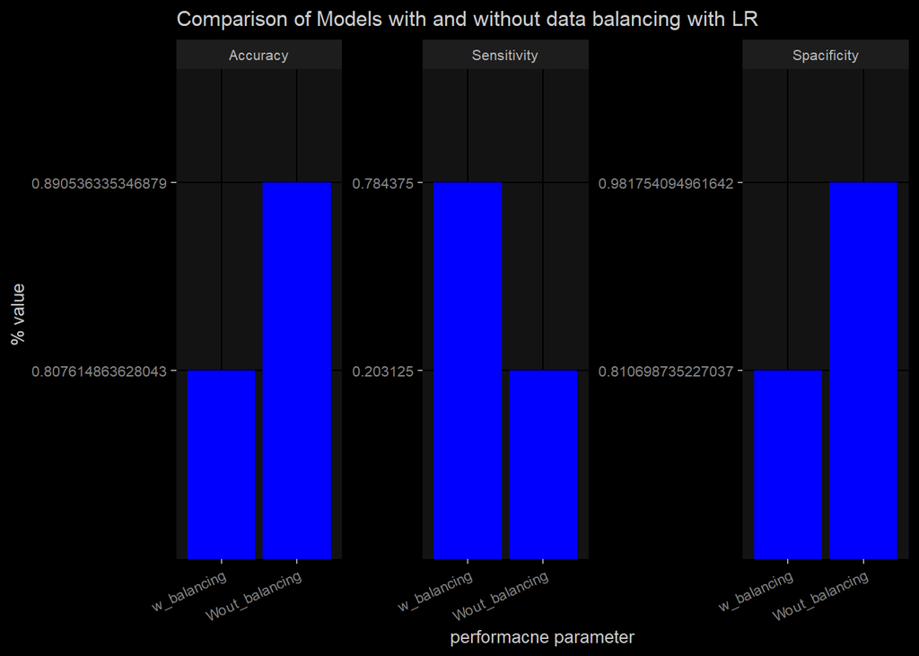

```r
df <- melt(performance_lr,id="Model")
p_lr <- ggplot(df,aes(Model,value))+geom_col(fill='blue')+ facet_wrap(~variable, scales = "free_y", ncol = 3)+
   theme(axis.text.x = element_text(angle = 25, vjust = 1, hjust = 1))+labs(x="performacne parameter",y="% value",title="Comparison of Models with and without data balancing with LR")
p_lr
```

## Comparing the 2 models

[output not shown]

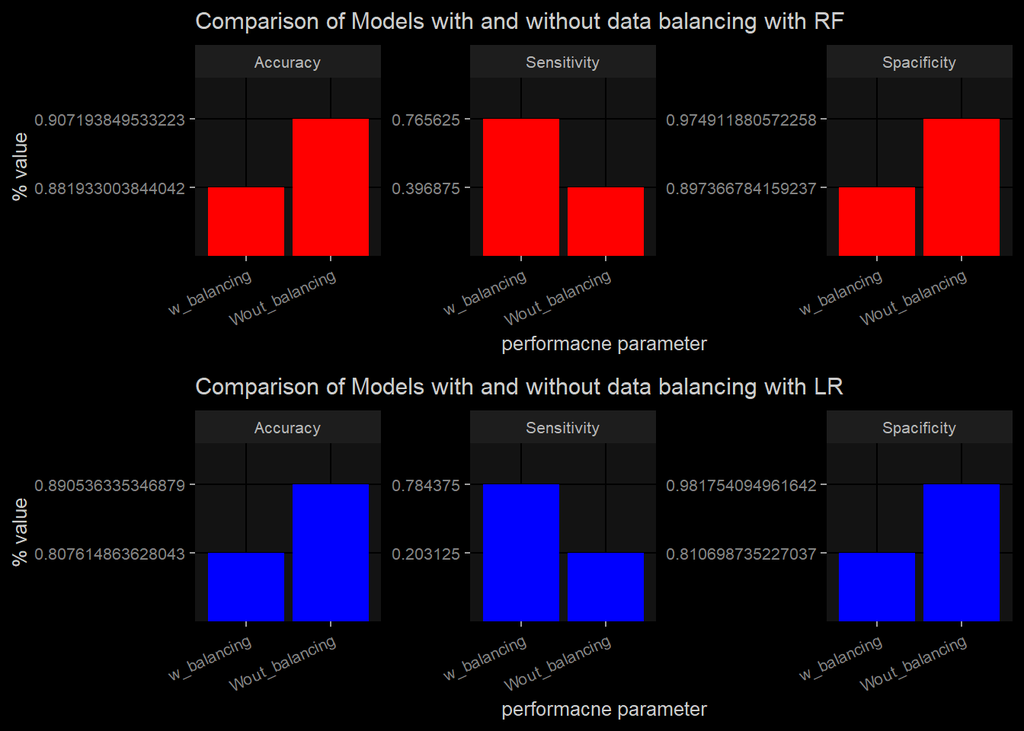

## Effort to make the model more robust with cross validation and hyper parameter tuning

model Development

```r
# Random Search
start2 <- proc.time()# Starting the clock
control <- trainControl(method="cv", number=5, search="random")
set.seed(555)
mtry <- sqrt(ncol(both))
rf_random <- train(labels~., data=both, method="rf", metric="Accuracy", tuneLength=5, trControl=control)
stop2 <- proc.time()# Stopping the clock
```

```
## Random Forest
##
## 20000 samples
##    12 predictor
##     2 classes: '0', '1'
##
## No pre-processing
## Resampling: Cross-Validated (5 fold)
## Summary of sample sizes: 16000, 16000, 16000, 16000, 16000
## Resampling results across tuning parameters:
##
##   mtry  Accuracy  Kappa
##   1     0.83280   0.6655178
##   4     0.95665   0.9133484
##   5     0.95615   0.9123473
##   8     0.95550   0.9110491
##
## Accuracy was used to select the optimal model using the largest value.
## The final value used for the model was mtry = 4.
```

### Timing the model

```
##    user  system elapsed
##  217.66    6.60  224.46
```

[output not shown]

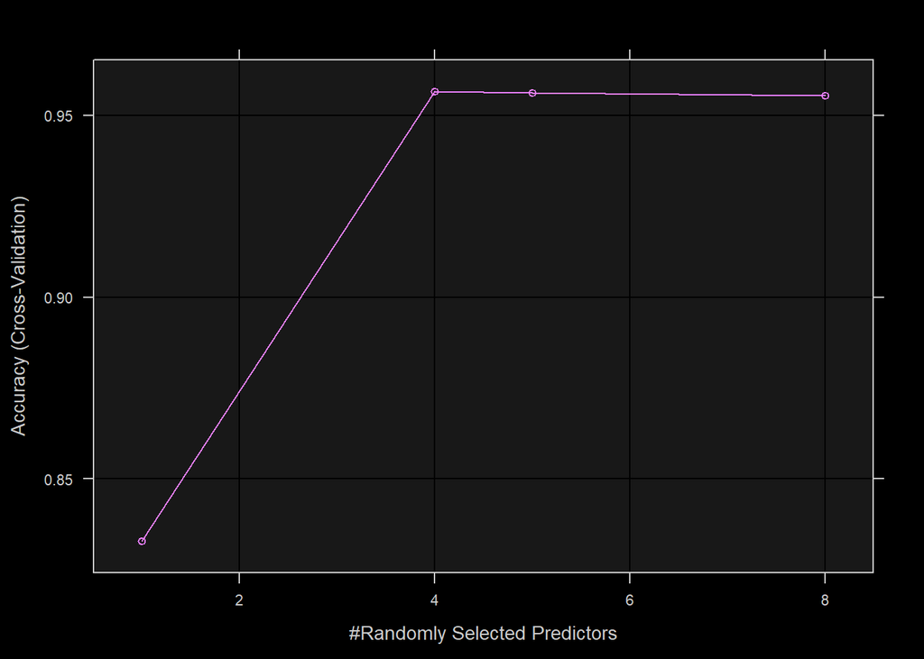

## Model Scoring on Test Data with random forest alogorithm

```r
set.seed=555
df_test_final <- df_test[,-c(3,8,11,7)]
df_test_final$labels <- as.factor(df_test_final$labels)
confusionMatrix(predict(rf_random,df_test_final),df_test_final$labels,positive='1')
```

```
## Confusion Matrix and Statistics
##
##           Reference
## Prediction    0    1
##          0 5372  210
##          1  625  575
##
##                Accuracy : 0.8769
##                  95% CI : (0.8688, 0.8846)
##     No Information Rate : 0.8843
##     P-Value [Acc > NIR] : 0.9716
##
##                   Kappa : 0.5109
##
##  Mcnemar's Test P-Value : <2e-16
##
##             Sensitivity : 0.73248
##             Specificity : 0.89578
##          Pos Pred Value : 0.47917
##          Neg Pred Value : 0.96238
##              Prevalence : 0.11575
##          Detection Rate : 0.08478
##    Detection Prevalence : 0.17694
##       Balanced Accuracy : 0.81413
##
##        'Positive' Class : 1
##
```

## Bench Mark Accuracy for the model

```r
t <- prop.table(table(df_train$labels))
bm_churn <- round(t[[2]]*100,2)
bm_no_churn <- round(t[[1]]*100,2)
```

```r
cat("Bench mark Accuracy for Churn:",bm_churn,"% \n")
```

```
## Bench mark Accuracy for Churn: 11.73 %
```

```r
cat("Bench mark Accuracy for No Churn:",bm_no_churn,"%")
```

```
## Bench mark Accuracy for No Churn: 88.27 %
```

[output not shown]

# Model Interpretation and Inference

This is our final model that has generalized the test data quite well. I am happy with the performance , specially predicting the ‘churn’ of the customer is at satisfactory level(appx.74% compared to the bench mark accuracy 12% for the imbalanced data set).The other measures are also satisfactory specially the accuracy which is (appx. 88%) close to our bench mark accuracy .In terms of model time complexity , with 5 fold cross validation model took `224.46 sec, compared to model without cross validation`13.68 sec with the same level of accuracy.The time complexity increases exponentially with the cross validation tuned for parameters for higher values. I have run in one instance for number of folds=10, tunelength=10,.ntree=500 and waited for 40 minutes still the model was training and i had to shut down the process manually.

So we should consider this time factor in terms of model training and it should justify how much gain in performance we are getting at the expense of how much time we are investing and take our final decision in model selection.

Based on the above discussion we should go for a simple random forest model without cross validation as implementing cross validation does not add much value in gaining improvements in the performance compared to time and efforts it takes to achieve similar level of performance.

# Marketing Suggestions

Below are some suggestions regarding Churn Rate in Marketing Perspective derived from the analysis:

1. If our Business goal is identifying whether a customer will churn or not, we should give more focus on the accuracy on the level 1 of our target data set.
2. For this, we can tune some parameters like cut off points to a higher thresh-hold value which will increase the predicting accuracy of churn rate.
3. We have identified, feature_3 is the most important predictor in case of predicting the churn or No Churn of the customer.

```
## Confusion Matrix and Statistics
##
##           Reference
## Prediction    0    1
##          0 3626  239
##          1 1197  401
##
##                Accuracy : 0.7371
##                  95% CI : (0.7253, 0.7488)
##     No Information Rate : 0.8828
##     P-Value [Acc > NIR] : 1
##
##                   Kappa : 0.2294
##
##  Mcnemar's Test P-Value : <2e-16
##
##             Sensitivity : 0.6266
##             Specificity : 0.7518
##          Pos Pred Value : 0.2509
##          Neg Pred Value : 0.9382
##              Prevalence : 0.1172
##          Detection Rate : 0.0734
##    Detection Prevalence : 0.2925
##       Balanced Accuracy : 0.6892
##
##        'Positive' Class : 1
##
```

This predictor alone can explain the target variable well with the accuracy of 73% and sensitivity of 63%. So, we should invest more time on the specifics of this variable for a customer and find ways to communicate and create several indicators in case something goes wrong about the customer based on this feature and give the highest priority in mitigating any obstacles the customer might have with respect to this feature.

4. In order to retain the customer (retention is less costly than acquiring a new customer), the company must focus on the top 5 features which are related to customer(in our case feature_3,feature_11,feature_13,feature_5 and feature_4) and find ways to improve customer experience or target specific customer groups for promotional activities tailored for these customers for better customer experience and increase their loyalty towards the company.

# Conclusion

Overall, this was a challenging assignment for me. Specially performing the Exploratory data analysis part . My main objective was to learn how to explore the data step by step in reaching certain goal and I believe I have I have achieved that learning goal.The learning curve was high for me, although I was familiar with the techniques, however, I had to figure out suitable implementations for the project which was challenging.In the process I learnt a lot about different R packages for Exploratory analysis and model building and evaluation.Finally, while performing the fine tuning,I found that tuning the hyper parameters are relatively time consuming and require lots of patience and it is not easy as it seems to be.

I have thoroughly enjoyed the assignment and gained valuable knowledge from it.

# *References*

Brownlee, J. (2020). Tune Machine Learning Algorithms in R. Random Forest case study. https://machinelearningmastery.com/tune-machine-learning-algorithms-in-r/

Confusion Matrix. (2021, July 4). In Wikipedia. https://en.wikipedia.org/wiki/Confusion_matrix

Kuhn, M. (2019). The caret Package. https://topepo.github.io/caret/model-training-and-tuning.html

Powers, D. M. W. (2011). Evaluation: From Precision, Recall and F-Measure to ROC, Informedness, Markedness & Correlation. Journal of Machine Learning Technologies. 2 (1): 37–63. https://arxiv.org/ftp/arxiv/papers/2010/2010.16061.pdf

Rai, B. (2017, June 6). Handling Class Imbalance Problem in R: Improving Predictive Model Performance [Video]. https://www.youtube.com/watch?v=Ho2Klvzjegg&t=244s

Rai, B. (2018, October 17). Logistic Regression with R: Categorical Response Variable at Two Levels. [Video]. https://www.youtube.com/watch?v=AVx7Wc1CQ7Y&t=1s

Soetewey, A. (2020). Correlation coefficient and correlation test in R. https://statsandr.com/blog/correlation-coefficient-and-correlation-test-in-r/